# Geospatial Risk Prediction in Chicago IL

By Stephanie Onuaja

October 27, 2022

## 0.1 Introduction

Using geospatial risk modeling tools commonly referred to as “predictive policing”, I built a model to forecast the risk of criminal property damage in Chicago. Predictive Policing is a set of algorithms that have been employed by the public sector to predict the location, and the doer of crime as well as the judicial response to crime.

With the assumption that crime is a function of exposure to a series of geospatial risk and protective factors, two features were added to the model that accounts for the risk factors that impact and increase crime risk. This model will explore the spatial risk factors that would increase the risk of a property being damaged.

Due to the perpetuated discriminatory and disproportionate policing that targets Black and Brown neighborhoods, it is inherent that recorded crime would reflect the criminalization of some communities and races more than others. Thus, the predictions of future crime risk would be biased and could reproduce the dangerous policing measures that over-police communities of color.

#### 0.1.0.1 Setup

Using data from the City of Chicago’s Open Data Portal, I pulled data on police districts, police beats, criminal property damage, and the city’s boundary.

```r
# Read in Data from Chicago
policeDistricts <-
  st_read("https://data.cityofchicago.org/api/geospatial/fthy-xz3r?method=export&format=GeoJSON") %>%
  st_transform('ESRI:102271') %>%
  dplyr::select(District = dist_num)
## Reading layer `OGRGeoJSON' from data source
##   `https://data.cityofchicago.org/api/geospatial/fthy-xz3r?method=export&format=GeoJSON'
##   using driver `GeoJSON'
## Simple feature collection with 25 features and 2 fields
## Geometry type: MULTIPOLYGON
## Dimension:     XY
## Bounding box:  xmin: -87.94011 ymin: 41.64455 xmax: -87.52414 ymax: 42.02303
## Geodetic CRS:  WGS 84

policeBeats <-
  st_read("https://data.cityofchicago.org/api/geospatial/aerh-rz74?method=export&format=GeoJSON") %>%
  st_transform('ESRI:102271') %>%
  dplyr::select(District = beat_num)
## Reading layer `OGRGeoJSON' from data source
##   `https://data.cityofchicago.org/api/geospatial/aerh-rz74?method=export&format=GeoJSON'
##   using driver `GeoJSON'
## Simple feature collection with 277 features and 4 fields
## Geometry type: MULTIPOLYGON
## Dimension:     XY
## Bounding box:  xmin: -87.94011 ymin: 41.64455 xmax: -87.52414 ymax: 42.02303
## Geodetic CRS:  WGS 84

bothPoliceUnits <- rbind(mutate(policeDistricts, Legend = "Police Districts"),
                         mutate(policeBeats, Legend = "Police Beats"))

# Including Property Damage Data
Damages <-
  read.socrata("https://data.cityofchicago.org/Public-Safety/Crimes-2017/d62x-nvdr") %>%
    filter(Primary.Type == "CRIMINAL DAMAGE" & Description == "TO PROPERTY") %>%
    mutate(x = gsub("[()]", "", Location)) %>%
    separate(x,into= c("Y","X"), sep=",") %>%
    mutate(X = as.numeric(X),Y = as.numeric(Y)) %>%
    na.omit() %>%
    st_as_sf(coords = c("X", "Y"), crs = 4326, agr = "constant")%>%
    st_transform('ESRI:102271') %>%
    distinct()

chicagoBoundary <-
  st_read(file.path(root.dir,"/Chapter5/chicagoBoundary.geojson")) %>%
  st_transform('ESRI:102271')
## Reading layer `chicagoBoundary' from data source
##   `https://raw.githubusercontent.com/urbanSpatial/Public-Policy-Analytics-Landing/master/DATA///Chapter5/chicagoBoundary.geojson'
##   using driver `GeoJSON'
## Simple feature collection with 1 feature and 1 field
## Geometry type: POLYGON
## Dimension:     XY
## Bounding box:  xmin: -87.8367 ymin: 41.64454 xmax: -87.52414 ymax: 42.02304
## Geodetic CRS:  WGS 84
```

#### 0.1.0.2 Visualizing Property Damage in Point Form and Density Plot

I decided to look at criminal property damage. Selection bias would arise because the data would be limited to reported cases, so it may not fully represent where the crimes are occurring. From the density plots, we see that most of the reported cases are in West Chicago and South Chicago.

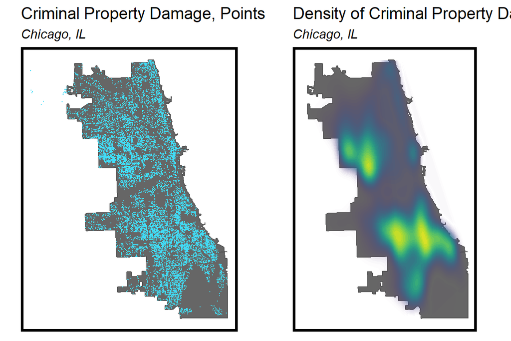

```r
grid.arrange(ncol=2,
ggplot() +
  geom_sf(data = chicagoBoundary, fill = "grey40") +
  geom_sf(data = Damages, colour="#41dbf7", size=0.1, show.legend = "point") +
  labs(title= "Criminal Property Damage, Points",
       subtitle= "Chicago, IL") +
  mapTheme(title_size = 14),

ggplot() +
  geom_sf(data = chicagoBoundary, fill = "grey40") +
  stat_density2d(data = data.frame(st_coordinates(Damages)),
                 aes(X, Y, fill = ..level.., alpha = ..level..),
                 size = 0.01, bins = 40, geom = 'polygon') +
  scale_fill_viridis() +
  scale_alpha(range = c(0.00, 0.35), guide = FALSE) +
  labs(title = "Density of Criminal Property Damage",
       subtitle= "Chicago, IL") +
  mapTheme(title_size = 14) + theme(legend.position = "none"))
```

## 0.2 Data Wrangling

#### 0.2.0.1 Creating a Fishnet Grid

```r
fishnet <-
  st_make_grid(chicagoBoundary,
               cellsize = 500,
               square = TRUE) %>%
  .[chicagoBoundary] %>%
  st_sf() %>%
  mutate(uniqueID = 1:n())

# Aggregate Damages to Property Points to the Fishnet
crime_net <-
  dplyr::select(Damages) %>%
  mutate(countDamages = 1) %>%
  aggregate(., fishnet, sum) %>%
  mutate(countDamages = replace_na(countDamages, 0),
         uniqueID = 1:n(),
         cvID = sample(round(nrow(fishnet) / 24),
                       size=nrow(fishnet), replace = TRUE))
```

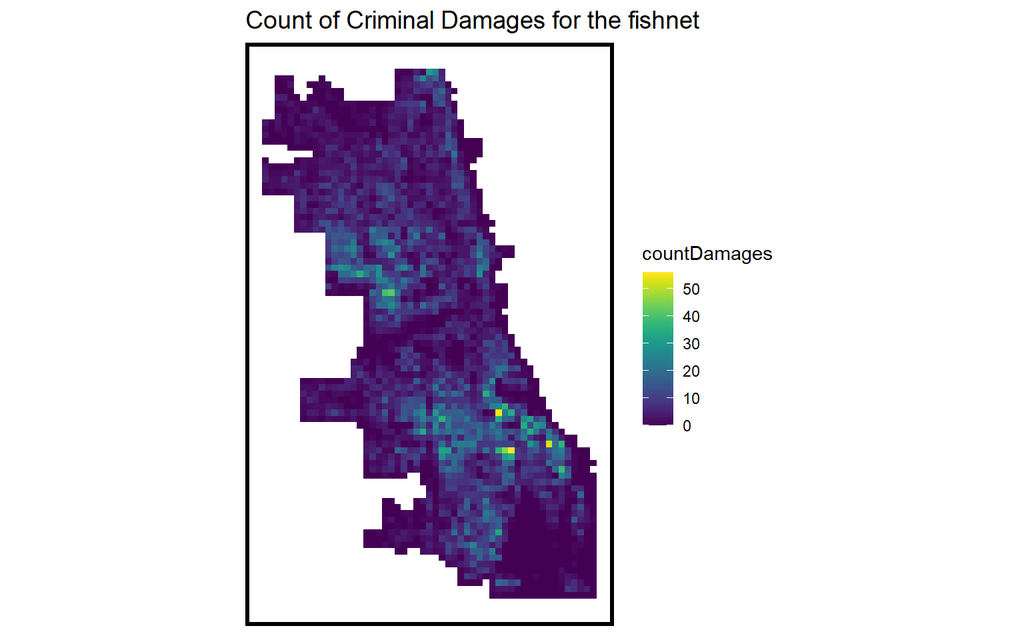

```r
ggplot() +
  geom_sf(data = crime_net, aes(fill = countDamages), color = NA) +
  scale_fill_viridis() +
  labs(title = "Count of Criminal Damages for the fishnet") +
  mapTheme(title_size = 14)
```

#### 0.2.0.2 Modeling Spatial Features

I selected noise complaints and affordable housing rental developments as potential spatial risk factors that could impact the occurrence of criminal property damage.

```r
Noise <-
  read.socrata("https://data.cityofchicago.org/Environment-Sustainable-Development/CDPH-Environmental-Complaints/fypr-ksnz") %>%
    mutate(year = substr(complaint_date,1,4)) %>%  filter(year == "2018") %>%
    filter(complaint_type == "NOISE COMPLAINT")%>%
    dplyr::select(Y = latitude, X = longitude) %>%
    na.omit() %>%
    st_as_sf(coords = c("X", "Y"), crs = 4326, agr = "constant") %>%
    st_transform(st_crs(fishnet)) %>%
    mutate(Legend = "Noise_Complaints")

AfforHousing <-
  read.socrata("https://data.cityofchicago.org/Community-Economic-Development/Affordable-Rental-Housing-Developments/s6ha-ppgi") %>%
    dplyr::select(Y = latitude, X = longitude) %>%
    na.omit() %>%
    st_as_sf(coords = c("X", "Y"), crs = 4326, agr = "constant") %>%
    st_transform(st_crs(fishnet)) %>%
    mutate(Legend = "Affordable_Housing")

neighborhoods <-
  st_read("https://raw.githubusercontent.com/blackmad/neighborhoods/master/chicago.geojson")%>%
  st_transform(st_crs(fishnet))
## Reading layer `chicago' from data source
##   `https://raw.githubusercontent.com/blackmad/neighborhoods/master/chicago.geojson'
##   using driver `GeoJSON'
## Simple feature collection with 98 features and 4 fields
## Geometry type: MULTIPOLYGON
## Dimension:     XY
## Bounding box:  xmin: -87.94011 ymin: 41.64454 xmax: -87.52414 ymax: 42.02304
## Geodetic CRS:  WGS 84

# Aggregate a feature to our fishnet

vars_net <-
  rbind(Noise, AfforHousing) %>%
  st_join(., fishnet, join=st_within) %>%
  st_drop_geometry() %>%
  group_by(uniqueID, Legend) %>%
  summarize(count = n()) %>%
    full_join(fishnet) %>%
    spread(Legend, count, fill=0) %>%
    st_sf() %>%
    dplyr::select(-`<NA>`) %>%
    na.omit() %>%
    ungroup()
## `summarise()` has grouped output by 'uniqueID'. You can override using the
## `.groups` argument.
## Joining, by = "uniqueID"
```

## 0.3 Feature Engineering

#### 0.3.0.1 Nearest Neighbor Features

The nearest neighbor feature converts the grid cells into centroids and measures to k risk factor points. (k=3)

```r
st_c    <- st_coordinates
st_coid <- st_centroid

## create NN from noise and affordable housing units
vars_net <- vars_net %>%
    mutate(Noise.nn = nn_function(st_c(st_coid(vars_net)),
                                           st_c(Noise),
                                           k = 3))
   vars_net <- vars_net %>%
     mutate(AfforHousing.nn = nn_function(st_c(st_coid(vars_net)),
                                          st_c(AfforHousing),3))

vars_net.long.nn <-
  dplyr::select(vars_net, ends_with(".nn")) %>%
    gather(Variable, value, -geometry)
```

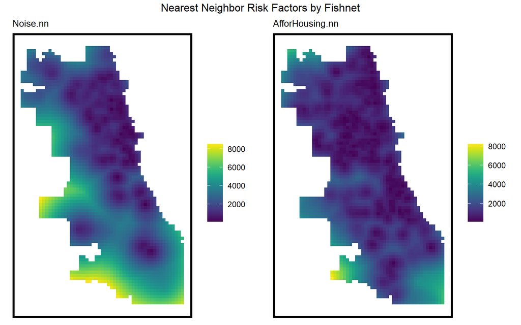

```r
# Visualizing NN features
vars <- unique(vars_net.long.nn$Variable)
mapList <- list()

for(i in vars){
  mapList[[i]] <-
    ggplot() +
      geom_sf(data = filter(vars_net.long.nn, Variable == i), aes(fill=value), colour=NA) +
      scale_fill_viridis(name="") +
      labs(title=i) +
      mapTheme(title_size = 10)}

do.call(grid.arrange,c(mapList, ncol = 2, top = "Nearest Neighbor Risk Factors by Fishnet"))
```

```r
final_net <-
  left_join(crime_net, st_drop_geometry(vars_net), by="uniqueID")

### Join in areal data
final_net <-
  st_centroid(final_net) %>%
    st_join(dplyr::select(neighborhoods, name), by = "uniqueID") %>%
    st_join(dplyr::select(policeDistricts, District), by = "uniqueID") %>%
      st_drop_geometry() %>%
      left_join(dplyr::select(final_net, geometry, uniqueID)) %>%
      st_sf() %>%
  na.omit()
## Joining, by = "uniqueID"
```

#### 0.3.0.2 Measure Distance to One Point

The distance to Chicago’s Central Business District (the Loop) was measured.

```r
loopPoint <-
  filter(neighborhoods, name == "Loop") %>%
  st_centroid()

vars_net$loopDistance =
  st_distance(st_centroid(vars_net),loopPoint) %>%
  as.numeric()
```

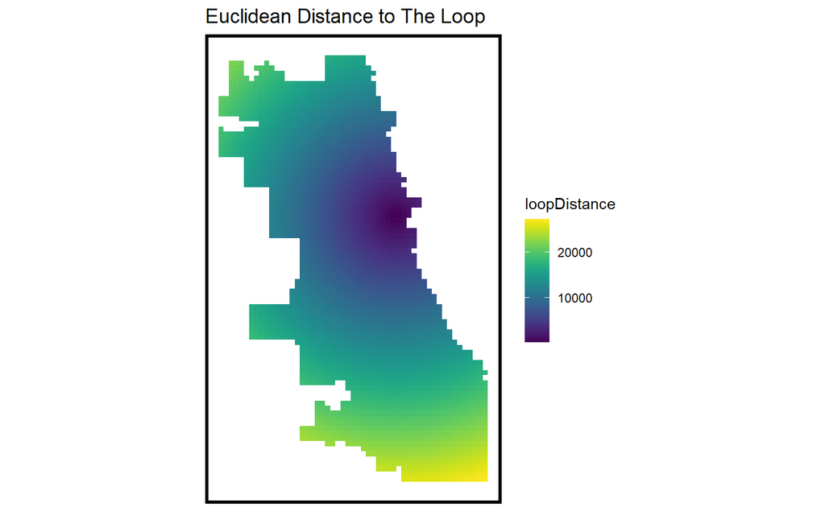

```r
ggplot() +
  geom_sf(data = vars_net, aes(fill = loopDistance ), color = NA) +
  scale_fill_viridis() +
  labs(title = "Euclidean Distance to The Loop") +
  mapTheme(title_size = 14)
```

#### 0.3.0.3 Local Moran’s I

The Local Moran’s describes the local spatial process of criminal property damage. That is how property damage counts relate to their neighbors.

```r
# Weights
final_net.nb <- poly2nb(as_Spatial(final_net), queen=TRUE)

final_net.weights <- nb2listw(final_net.nb, style="W", zero.policy=TRUE)

# Local Moran's I
local_morans <- localmoran(final_net$countDamages, final_net.weights, zero.policy=TRUE) %>%
  as.data.frame()

# join local Moran's I results to fishnet
final_net.localMorans <-
  cbind(local_morans, as.data.frame(final_net)) %>%
  st_sf() %>%
  dplyr::select(countDamages = countDamages,
                Local_Morans_I = Ii,
                P_Value = `Pr(z != E(Ii))`) %>%
  mutate(Significant_Hotspots = ifelse(P_Value <= 0.001, 1, 0)) %>%
  gather(Variable, Value, -geometry)
```

The relatively high values of I on the map represent strong and statistically significant evidence of local clustering. The smaller the p-value the more significant the clusters.

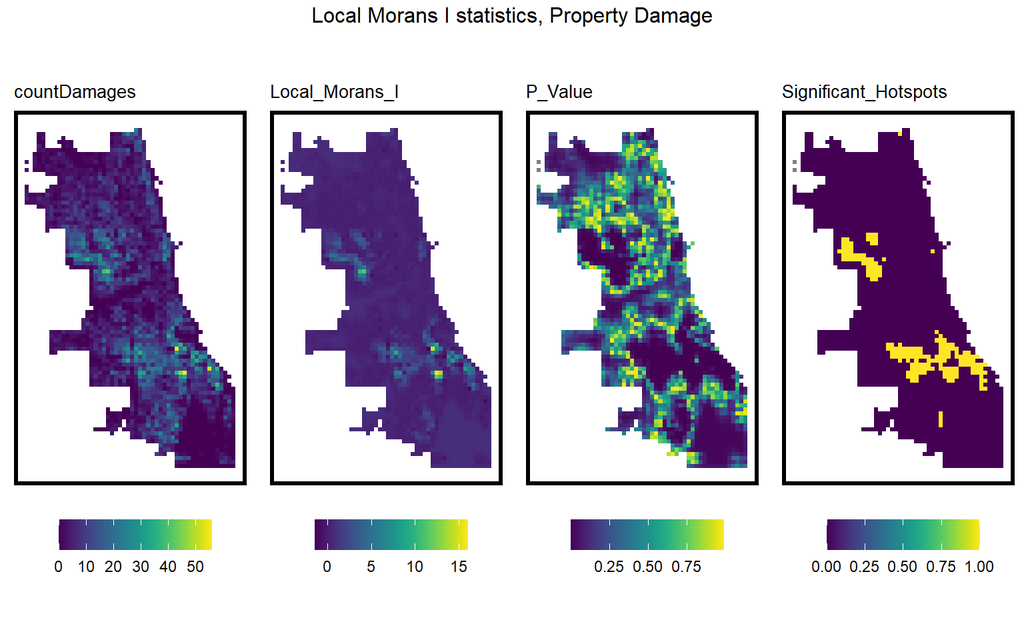

```r
vars <- unique(final_net.localMorans$Variable)
varList <- list()

for(i in vars){
  varList[[i]] <-
    ggplot() +
      geom_sf(data = filter(final_net.localMorans, Variable == i),
              aes(fill = Value), colour=NA) +
      scale_fill_viridis(name="") +
      labs(title=i) +
      mapTheme(title_size = 10) + theme(legend.position="bottom")}

do.call(grid.arrange,c(varList, ncol = 4, top = "Local Morans I statistics, Property Damage"))
```

#### 0.3.0.4 Distance to Hot spot

This map shows the average nearest neighbor distance from each cell centroid to its nearest significant cluster.

```r
final_net <- final_net %>%
  mutate(Damages.isSig =
           ifelse(local_morans[,5] <= 0.001, 1, 0)) %>%
  mutate(Damages.isSig.dist =
           nn_function(st_c(st_coid(final_net)),
                       st_c(st_coid(filter(final_net,
                                           Damages.isSig == 1))), k = 1))
```

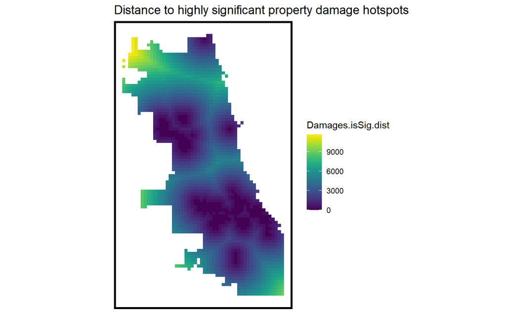

```r
### Plot NN distance to hot spot
ggplot() +
      geom_sf(data = final_net, aes(fill=Damages.isSig.dist), colour=NA) +
      scale_fill_viridis(name="Damages.isSig.dist") +
      labs(title="Distance to highly significant property damage hotspots") +
      mapTheme(title_size = 14)
```

#### 0.3.0.5 Correlation Plots

The correlation plots begin to show how well the spatial risk features would predict criminal property damage.

```r
correlation.long <-
  st_drop_geometry(final_net) %>%
    dplyr::select(-uniqueID, -cvID, -name, -District) %>%
    gather(Variable, Value, -countDamages)

correlation.cor <-
  correlation.long %>%
    group_by(Variable) %>%
    summarize(correlation = cor(Value, countDamages, use = "complete.obs"))
```

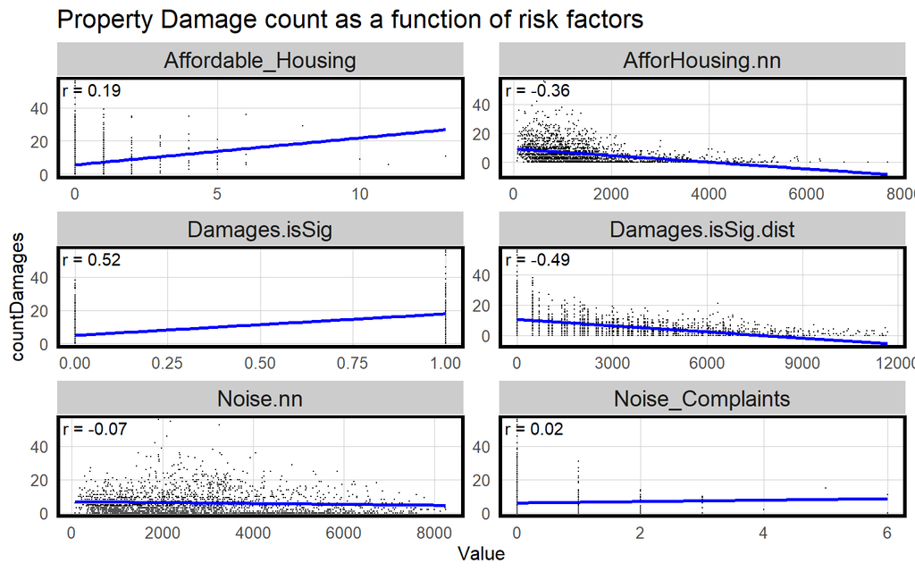

```r
ggplot(correlation.long, aes(Value, countDamages)) +
  geom_point(size = 0.1) +
  geom_text(data = correlation.cor, aes(label = paste("r =", round(correlation, 2))),
            x=-Inf, y=Inf, vjust = 1.5, hjust = -.1) +
  geom_smooth(method = "lm", se = FALSE, colour = "blue") +
  facet_wrap(~Variable, ncol = 2, scales = "free") +
  labs(title = "Property Damage count as a function of risk factors") +
  plotTheme()
## `geom_smooth()` using formula 'y ~ x'
```

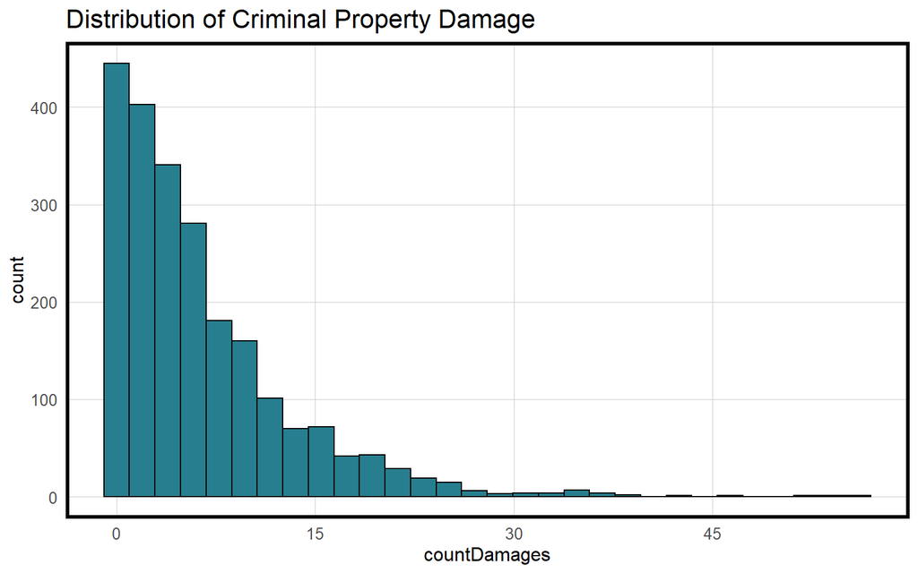

```r
ggplot(data = final_net, aes(countDamages))+
  geom_histogram(bins = 30, color = 'black', fill = "#277e8e") +
  scale_x_continuous(breaks = seq(0, 80, by = 15)) +
  labs(title = 'Distribution of Criminal Property Damage')+plotTheme()
```